# Homework 11

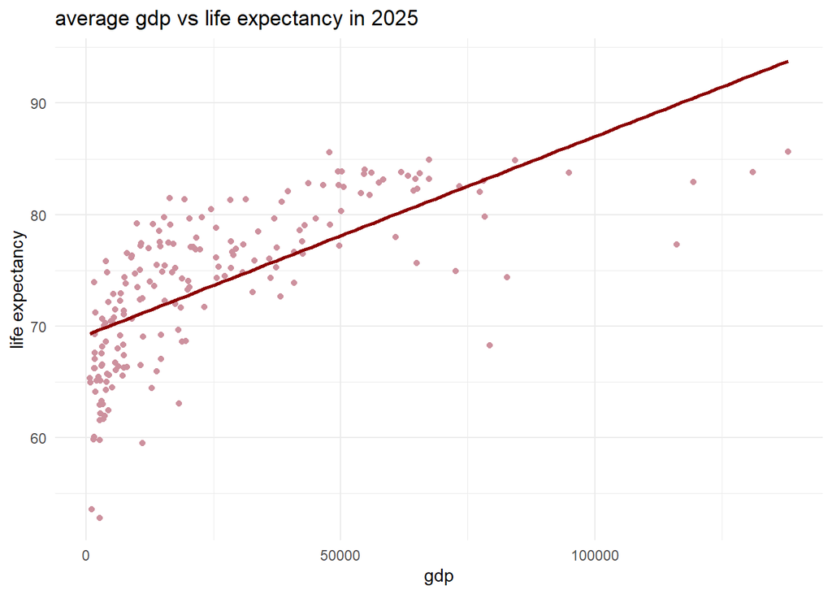

```r
gapminder%>%
  filter(year== "2025")%>%
  filter(country != "Monaco")%>%
  ggplot(aes(x=gdp, y=lex))+
  geom_jitter(color= "pink3")+
  geom_smooth(method = "lm", se=F, color= "darkred")+
  labs( title = "average gdp vs life expectancy in 2025",
        x= "gdp",
        y= "life expectancy")+
  theme_minimal()
```

8. Which five countries have had the highest absolute GDP per capita growth over the past 50 years? Show this as a table. (Suggestion! Remove Monaco as an extreme outlier.)

```r
gapminder%>%
  filter(year %in% c(1975, 2025))%>%
  filter(country!= "Monaco")%>%
  select(country, year, gdp)%>%
  arrange(country, year)%>%
  group_by(country)%>%
  summarise(mean_gdp= mean(gdp, na.rm=T))%>%
  arrange(desc(mean_gdp))
```

```
## # A tibble: 194 × 2
##    country     mean_gdp
##    <chr>          <dbl>
##  1 Brunei       107556.
##  2 Qatar        107450.
##  3 Luxembourg    80994.
##  4 Singapore     75401.
##  5 UAE           73529.
##  6 Ireland       66871.
##  7 Norway        60205.
##  8 Andorra       59832.
##  9 Switzerland   58549.
## 10 San Marino    58182.
## # ℹ 184 more rows
```

9. How does per capita GDP growth compare between these same five countries over the past 50 years? Show this as a plot.

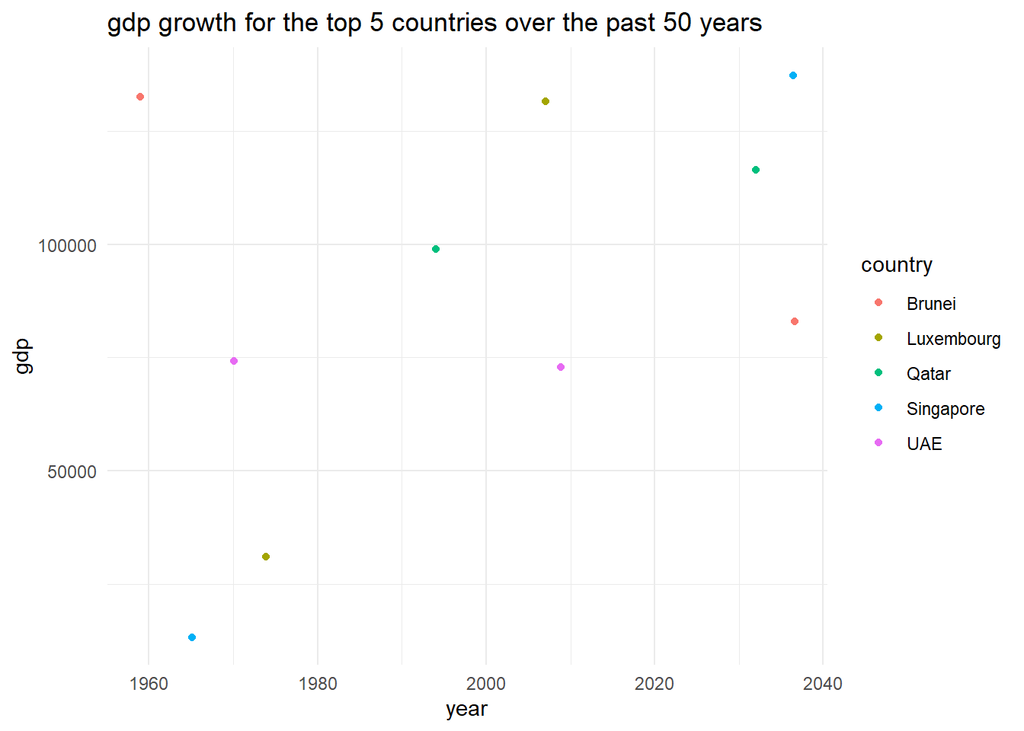

```r
gapminder%>%
  filter(country%in% c("Brunei", "Qatar", "Luxembourg", "Singapore", "UAE"))%>%
  filter(year%in% c(1975, 2025))%>%
  ggplot(aes(x=year, y=gdp, color= country))+
  #geom_line()+
  geom_jitter()+ #(method= "lm", se=F)
  labs( title= "gdp growth for the top 5 countries over the past 50 years",
        x="year",
        y= "gdp",
        color= "country")+
  theme_minimal()
```

10. Do one analysis of your choice that includes a table and plot as outputs.

```r
#what would a graph look like of the bottom 5 countries?
gapminder%>%
  filter(year %in% c(1975, 2025))%>%
  filter(country!= "Monaco")%>%
  select(country, year, gdp)%>%
  arrange(country, year)%>%
  group_by(country)%>%
  summarise(mean_gdp= mean(gdp, na.rm=T))%>%
  arrange(mean_gdp)
```

```
## # A tibble: 194 × 2
##    country                  mean_gdp
##    <chr>                       <dbl>
##  1 Burundi                      883.
##  2 Mozambique                  1064.
##  3 South Sudan                 1154.
##  4 Central African Republic    1234.
##  5 Malawi                      1322.
##  6 Somalia                     1364.
##  7 Niger                       1575.
##  8 Eritrea                     1714.
##  9 Congo, Dem. Rep.            1751.
## 10 Burkina Faso                1811.
## # ℹ 184 more rows
```

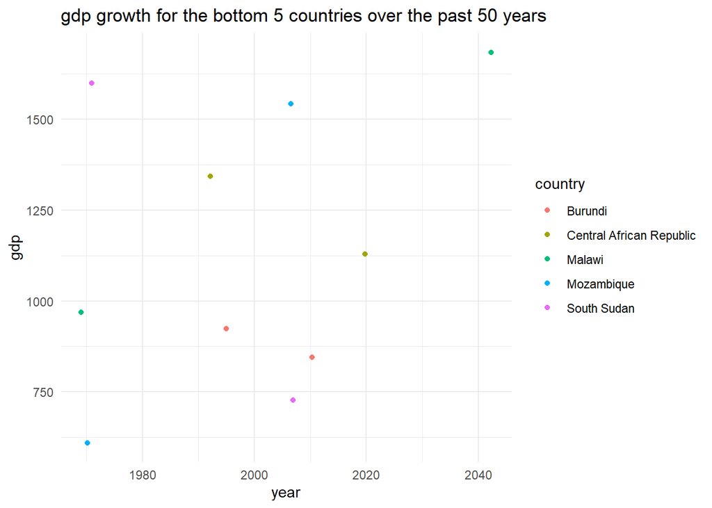

```r
gapminder%>%
  filter(country%in% c("Burundi", "Mozambique", "South Sudan", "Central African Republic", "Malawi"))%>%
  filter(year%in% c(1975, 2025))%>%
  ggplot(aes(x=year, y=gdp, color= country))+
  #geom_line()+
  geom_jitter()+ #(method= "lm", se=F)
  labs( title= "gdp growth for the bottom 5 countries over the past 50 years",
        x="year",
        y= "gdp",
        color= "country")+
  theme_minimal()
```

## Knit and Upload

Please knit your work as an .html file and upload to Canvas. Homework is due before the start of the next lab. No late work is accepted. Make sure to use the formatting conventions of RMarkdown to make your report neat and clean!